# BIOL343 Coding Challenge 4

Group 6 — Victoria Gutierrez 20517120

October 9th, 2026

# BIOL343 Coding Challenge 4

## Group Members

```r
# Name - Queen's Student Number

# 1. Onna Esme - 20307366
# 2. Victoria Gutierrez - 20517120
# 3. Ellie Maki - 20419523
# 4. Jake Mayo - 20186062
# 5. Archi Patel - 20475426
```

# DO THIS FIRST

Copy and paste this into your R Console to start positpal, but replace `FILENAME.Rmd` with the name you are going to use for the .R or .Rmd file you are going to upload (rename the template first, e.g. `Group_#_CC4.Rmd`, and use that exact name). **Do not include it as a code chunk.**

```
install.packages("remotes")
remotes::install_url("https://quantitative.bio/downloads/positpal.tar.gz", upgrade = "never")
positpal::start("FILENAME.Rmd")
```

Before you run it: create or open an R project folder so that it is your working directory, then save this file in that folder under the name you will upload, and check that autosave is on (*File → Auto Save*). See OnQ and use the positpal chatbot if you are having trouble with positpal.

# Part 1 — Import and inspect

The data file is `data/AbroniaFloralData.csv`: one row per plant, from 12 coastal sites, with the mating system of the site (`self_inc`: SI or SC), the site’s latitude, and four floral traits. The instructions describe the study and the two hypotheses. **Do not edit the file by hand.**

## 1. Import the data

Import the observations and save it as an object called `floral_data`.

```r
floral_data <- read.csv("./data/AbroniaFloralData.csv")
```

## 2. Inspect the data

Check the object with `dim()`, `head()`, `str()` and `summary()`. Look for the usual problems: columns of the wrong type, and missing values.

```r
dim(floral_data)
```

```
## [1] 966   8
```

```r
head(floral_data)
```

```
##   self_inc site latitude_N     plant_id umbel_angle_deg flower_number face_diam_mm tube_length_mm
## 1       SI CMGA   34.22204  CMGA.2010.1             140            18        11.24         13.080
## 2       SI CMGA   34.22204 CMGA.2010.10              90             8        10.51         12.315
## 3       SI CMGA   34.22204 CMGA.2010.11             120            18        11.14         13.880
## 4       SI CMGA   34.22204 CMGA.2010.12             180            22        10.49         15.585
## 5       SI CMGA   34.22204 CMGA.2010.13             130            21        10.76         14.615
## 6       SI CMGA   34.22204 CMGA.2010.14              95            11        11.02         15.965
```

```r
str(floral_data)
```

```
## 'data.frame':    966 obs. of  8 variables:
##  $ self_inc       : chr  "SI" "SI" "SI" "SI" ...
##  $ site           : chr  "CMGA" "CMGA" "CMGA" "CMGA" ...
##  $ latitude_N     : num  34.2 34.2 34.2 34.2 34.2 ...
##  $ plant_id       : chr  "CMGA.2010.1" "CMGA.2010.10" "CMGA.2010.11" "CMGA.2010.12" ...
##  $ umbel_angle_deg: int  140 90 120 180 130 95 105 130 110 115 ...
##  $ flower_number  : int  18 8 18 22 21 11 10 16 14 12 ...
##  $ face_diam_mm   : num  11.2 10.5 11.1 10.5 10.8 ...
##  $ tube_length_mm : num  13.1 12.3 13.9 15.6 14.6 ...
```

```r
summary(floral_data)
```

```
##       self_inc          site       latitude_N         plant_id   umbel_angle_deg flower_number
##  Length   :966   Length   :966   Min.   :34.22   Length   :966   Min.   : 30.0   Min.   : 6.00
##  N.unique :  2   N.unique : 12   1st Qu.:34.41   N.unique :966   1st Qu.:100.0   1st Qu.:13.00
##  N.blank  :  0   N.blank  :  0   Median :35.30   N.blank  :  0   Median :110.0   Median :15.00
##  Min.nchar:  2   Min.nchar:  4   Mean   :36.21   Min.nchar: 11   Mean   :111.9   Mean   :15.44
##  Max.nchar:  2   Max.nchar:  5   3rd Qu.:36.95   Max.nchar: 13   3rd Qu.:125.0   3rd Qu.:17.00
##                                  Max.   :41.44                   Max.   :225.0   Max.   :28.00
##                                                                  NAs    :5
##   face_diam_mm    tube_length_mm
##  Min.   : 4.156   Min.   : 4.357
##  1st Qu.: 8.835   1st Qu.:11.992
##  Median :10.501   Median :13.096
##  Mean   :10.069   Mean   :12.628
##  3rd Qu.:11.499   3rd Qu.:14.172
##  Max.   :15.084   Max.   :19.100
##
```

**Question 1:** In statistical terms, what is the **statistical population** in this study, and what is the **sample**? Give one reason the sample might not be a random, unbiased sample of that population.

**Answer: the statistical population is all *Abronia umbellata* plants from self-incompatible (SI) and self-compatible (SC), while the sample consisst of the 966 plants measured from 12 sites from north of Los Angeles California to northern range limit in southern Oregon in the data. The sample may not be a completly random and unbiased sample because the plants were collected in a limited number of sites (12) with already known information of which type of mating systems would be found in these locations.**

# Part 2 — Distributions

## 3. Plot frequency distributions

Plot the distributions of `face_diam_mm`, with facets so that SI and SC plants are in separate panels. Choose an appropriate `binwidth` that shows the shape of the data distribution, add axis labels with units and a title, and use a ‘clean’ theme suitable for publication. Then do the same for `flower_number`, with `binwidth = 1`. If R prints a message about `bins = 30`, you have not set the binwidth; the chunk option `message=FALSE` (already set on these chunks) hides messages like that in the knitted file.

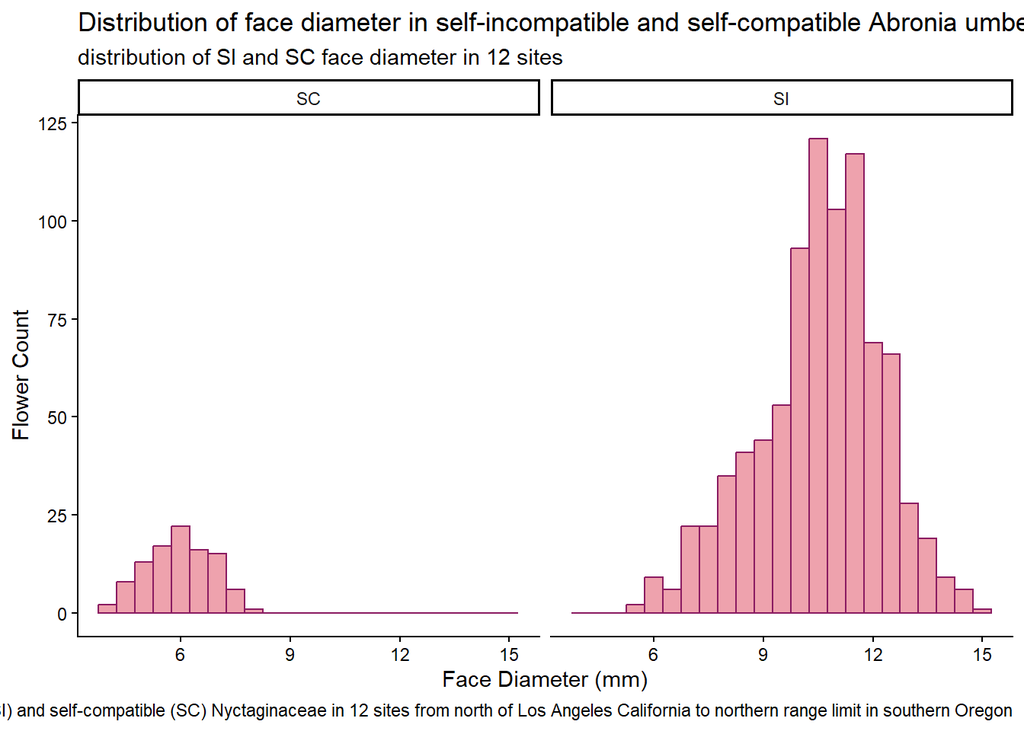

```r
library(ggplot2) # plotting library
source("http://bit.ly/theme_pub") # Set custom plotting themetheme_set(theme_pub())

face_diameter <- floral_data$face_diam_mm
ggplot(aes(x=face_diameter),data=floral_data) + geom_histogram(binwidth=0.5, colour="maroon4",fill="lightpink2") + facet_wrap(vars(self_inc)) + labs(title="Distribution of face diameter in self-incompatible and self-compatible Abronia umbellata", subtitle="distribution of SI and SC face diameter in 12 sites",caption="Figure 1: shows the distribution of face diameter in self-incompatible (SI) and self-compatible (SC) Nyctaginaceae in 12 sites from north of Los Angeles California to northern range limit in southern Oregon") + xlab("Face Diameter (mm)") + ylab("Flower Count") + theme_classic()
```

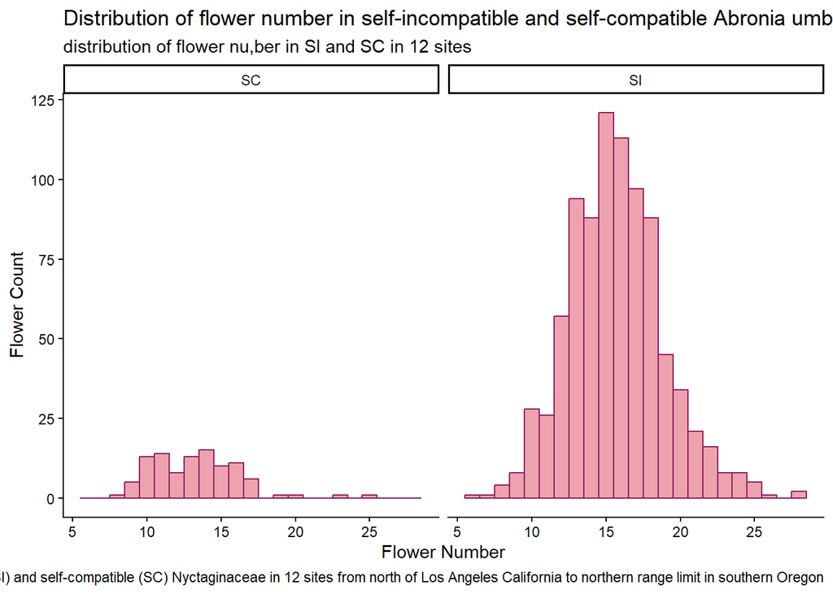

```r
flower_number <- floral_data$flower_number
ggplot(aes(x=flower_number),data=floral_data) + geom_histogram(binwidth=1, colour="maroon4",fill="lightpink2") + facet_wrap(vars(self_inc)) + labs(title="Distribution of flower number in self-incompatible and self-compatible Abronia umbellata", subtitle="distribution of flower nu,ber in SI and SC in 12 sites",caption="Figure 2: shows the distribution of flower number in self-incompatible (SI) and self-compatible (SC) Nyctaginaceae in 12 sites from north of Los Angeles California to northern range limit in southern Oregon") + xlab("Flower Number") + ylab("Flower Count") + theme_classic()
```

**Question 2:** Of the three common population distributions (Gaussian, Poisson, binomial), which one is the best model for `face_diam_mm`, and which for `flower_number`? Explain with respect to the *type* of data as well as the shape of the histogram.

## 4. Mean, standard deviation and coefficient of variation

Make two vectors, `SI` and `SC`, containing the face diameters of the SI plants and of the SC plants. For **each** vector, calculate the sample size, the mean, the standard deviation, and the coefficient of variation.

```r
library(tidyverse) # Loading Libraries

SI <- floral_data %>% filter(self_inc == "SI") %>% pull(face_diam_mm)

SC <- floral_data %>% filter(self_inc == "SC") %>% pull(face_diam_mm)

length(SI)
```

```
## [1] 866
```

```r
mean(SI, na.rm = TRUE)
```

```
## [1] 10.54396
```

```r
sd(SI, na.rm=TRUE)
```

```
## [1] 1.693516
```

```r
CV_SC <- sd(SI, na.rm=TRUE)/mean(SI, na.rm = TRUE)
print(CV)
```

```
## [1] 0.1606148
```

```r
length(SC)
```

```
## [1] 100
```

```r
mean(SC, na.rm = TRUE)
```

```
## [1] 5.960045
```

```r
sd(SC, na.rm=TRUE)
```

```
## [1] 0.8930541
```

```r
CV_SC <- sd(SC, na.rm=TRUE)/mean(SC, na.rm = TRUE)
print(CV)
```

[output not shown]

**Question 3:** The two standard deviations are very different, but the two coefficients of variation are almost the same. What does that tell you about how variation in flower size relates to mean flower size?

**Answer:The two coefficients of variation are almost the same as it represents that the variation scales with the mean flower size. SI has a larger group (866 plants) so it would have a larger standard deviation, though both groups show the same relative level of variation when expressed as a proportion of the mean (CV). So SI have more variability in terms of sample size, but no more than SC in terms of relative variation.**

## 5. Trait means by mating system and by site

Report the sample size and the mean of each of the four traits for SI and for SC plants, using `dplyr` commands. One trait has missing values, so the code must handle `NA`.

```r
# SI umbel angle degree
SI_umbel_angle <- floral_data %>% filter(self_inc == "SI") %>% summarise(mean=mean(umbel_angle_deg, na.rm = TRUE))
print(SI_umbel_angle)
```

```
##       mean
## 1 114.6195
```

```r
N_SI_umbel <- sum(!is.na(floral_data$umbel_angle_deg))
print(N_SI_umbel)
```

```
## [1] 961
```

```r
# SI flower number
SI_flower_number <- floral_data %>% filter(self_inc == "SI") %>% summarise(mean=mean(flower_number, na.rm = TRUE))
print(SI_flower_number)
```

```
##       mean
## 1 15.69053
```

```r
N_SI_flowernumber <- sum(!is.na(floral_data$flower_number))
print(N_SI_flowernumber)
```

```
## [1] 966
```

```r
# SI face diameter (mm)
SI_face_diameter <- floral_data %>% filter(self_inc == "SI") %>% summarise(mean=mean(face_diam_mm, na.rm = TRUE))
print(SI_face_diameter)
```

```
##       mean
## 1 10.54396
```

```r
N_SI_face_diameter <- sum(!is.na(floral_data$face_diam_mm))
print(N_SI_face_diameter)
```

```
## [1] 966
```

```r
# SI tube lenght (mm)
SI_tube_lenght <- floral_data %>% filter(self_inc == "SI") %>% summarise(mean=mean(tube_length_mm, na.rm = TRUE))
print(SI_tube_lenght)
```

```
##       mean
## 1 13.36932
```

```r
N_SI_tube_lenght <- sum(!is.na(floral_data$tube_length_mm))
print(N_SI_tube_lenght)
```

```
## [1] 966
```

```r
# SC umbel angle degree
SC_umbel_angle <- floral_data %>% filter(self_inc == "SC") %>% summarise(mean=mean(umbel_angle_deg, na.rm = TRUE))
print(SC_umbel_angle)
```

```
##       mean
## 1 88.28283
```

```r
N_SC_umbel <- sum(!is.na(floral_data$umbel_angle_deg))
print(N_SC_umbel)
```

```
## [1] 961
```

```r
# SC flower number
SC_flower_number <- floral_data %>% filter(self_inc == "SC") %>% summarise(mean=mean(flower_number, na.rm = TRUE))
print(SC_flower_number)
```

```
##    mean
## 1 13.27
```

```r
N_SC_flowernumber <- sum(!is.na(floral_data$flower_number))
print(N_SC_flowernumber)
```

```
## [1] 966
```

```r
# SC face diameter (mm)
SC_face_diameter <- floral_data %>% filter(self_inc == "SC") %>% summarise(mean=mean(face_diam_mm, na.rm = TRUE))
print(SC_face_diameter)
```

```
##       mean
## 1 5.960045
```

```r
N_SC_face_diameter <- sum(!is.na(floral_data$face_diam_mm))
print(N_SC_face_diameter)
```

```
## [1] 966
```

```r
# SC tube lenght (mm)
SC_tube_lenght <- floral_data %>% filter(self_inc == "SC") %>% summarise(mean=mean(tube_length_mm, na.rm = TRUE))
print(SC_tube_lenght)
```

```
##      mean
## 1 6.21289
```

```r
N_SC_tube_lenght <- sum(!is.na(floral_data$tube_length_mm))
print(N_SC_tube_lenght)
```

```
## [1] 966
```

Now make a second summary with one row per site: the site’s mating system, its latitude, the number of plants and the mean face diameter. Then plot mean face diameter (y) against latitude (x), one point per site, coloured by mating system, with axis labels with units, a legend title and a clean theme.

```r
site_means <- floral_data %>% group_by(site) %>% summarise(mean=mean(face_diam_mm, na.rm = TRUE), N_plants = n(), mating_sys  = first(self_inc), latitude_N = first(latitude_N))
```

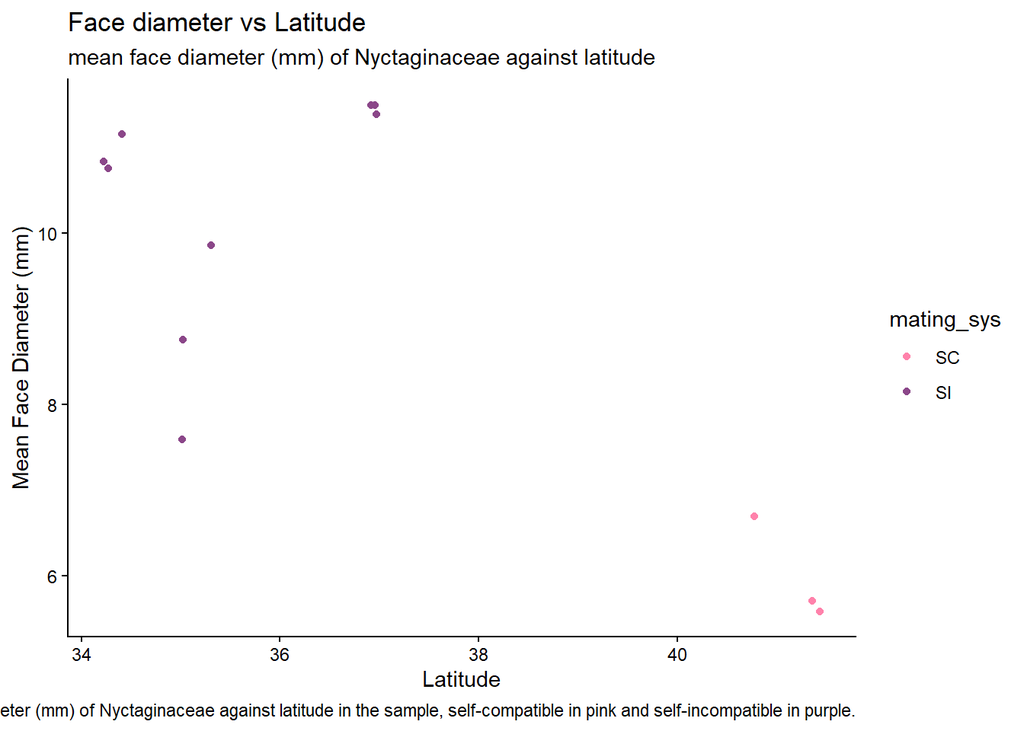

```r
ggplot(aes(x=latitude_N, y=mean), data=dplyr::filter(site_means, !is.na(mating_sys))) + geom_point(aes(colour=mating_sys)) + scale_colour_manual(values = c("palevioletred1", "orchid4")) + labs(title="Face diameter vs Latitude", subtitle="mean face diameter (mm) of Nyctaginaceae against latitude",caption="Figure 3: shows mean face diameter (mm) of Nyctaginaceae against latitude in the sample, self-compatible in pink and self-incompatible in purple.") + xlab("Latitude") + ylab("Mean Face Diameter (mm)") + theme_classic()
```

**Question 4:** Do the four traits differ between SI and SC plants in the direction predicted by the second hypothesis in the instructions? Which trait shows the largest relative difference?

# Part 3 — From the sample to the population

## 6. Standard error and confidence interval

For `SI` and for `SC`, calculate the standard error of the mean and the 95% confidence interval **from the equations**: $SE = s / \sqrt{n}$ and $CI = \bar x \pm 1.96 \times SE$. Print both intervals.

```r
SI_SE_Conf <- floral_data %>% filter(self_inc == "SI") %>% summarise(n = sum(!is.na(face_diam_mm)), mean = mean(face_diam_mm, na.rm = TRUE), SD = sd(face_diam_mm, na.rm = TRUE), SE = SD / sqrt(n), CI_lower = mean - 1.96 * SE, CI_upper = mean + 1.96 * SE)
print(SI_SE_Conf)
```

```
##     n     mean       SD         SE CI_lower CI_upper
## 1 866 10.54396 1.693516 0.05754802 10.43116 10.65675
```

```r
SC_SE_Conf <- floral_data %>% filter(self_inc == "SC") %>% summarise(n = sum(!is.na(face_diam_mm)), mean = mean(face_diam_mm, na.rm = TRUE), SD = sd(face_diam_mm, na.rm = TRUE), SE = SD / sqrt(n), CI_lower = mean - 1.96 * SE, CI_upper = mean + 1.96 * SE)
print(SC_SE_Conf)
```

```
##     n     mean        SD         SE CI_lower CI_upper
## 1 100 5.960045 0.8930541 0.08930541 5.785006 6.135084
```

**Question 5:** What does each confidence interval represent? Do the two intervals overlap, and what does that suggest about the two populations?

**Answer:Each confidence interval represents the estimation of the population’s mean of face diameters that are consistent with the sample data. Hence, we are saying we are 95% confident that the TRUE population mean would lie within each of those intervals. SI and SC confidence intervals do not overlap, so the populations differ significantly in mean of face diameters (evidence for biological difference between the populations).**

## 7. The central limit theorem

Set the seed with `set.seed(343)`. Use `sample()` to draw a random sub-sample of 10 plants from `SI`, then one of 100, then one of 500. For each sub-sample report the mean, the standard deviation and the width of the 95% confidence interval (upper limit minus lower limit), and compare them with the values for all 866 SI plants from Sections 4 and 6.

```r
set.seed(343)
SI_data <- floral_data %>% filter(self_inc == "SI")

# For 10 plants
SI_10 <- SI_data %>% slice_sample(n=10)
data_10 <- SI_10 %>% summarise(n = sum(!is.na(face_diam_mm)), mean = mean(face_diam_mm, na.rm = TRUE), SD = sd(face_diam_mm, na.rm = TRUE), SE = SD / sqrt(n), CI_lower = mean - 1.96 * SE, CI_upper = mean + 1.96 * SE)
print(data_10)
```

```
##    n     mean       SD      SE CI_lower CI_upper
## 1 10 10.48767 1.905873 0.60269 9.306403 11.66895
```

```r
# For 100 plants
SI_100 <- SI_data %>% slice_sample(n=100)
data_100 <- SI_100 %>% summarise(n = sum(!is.na(face_diam_mm)), mean = mean(face_diam_mm, na.rm = TRUE), SD = sd(face_diam_mm, na.rm = TRUE), SE = SD / sqrt(n), CI_lower = mean - 1.96 * SE, CI_upper = mean + 1.96 * SE)
print(data_100)
```

```
##     n     mean       SD        SE CI_lower CI_upper
## 1 100 10.34448 1.739815 0.1739815 10.00348 10.68548
```

```r
# For 500 plants
SI_500 <- SI_data %>% slice_sample(n=500)
data_500 <- SI_500 %>% summarise(n = sum(!is.na(face_diam_mm)), mean = mean(face_diam_mm, na.rm = TRUE), SD = sd(face_diam_mm, na.rm = TRUE), SE = SD / sqrt(n), CI_lower = mean - 1.96 * SE, CI_upper = mean + 1.96 * SE)
print(data_500)
```

```
##     n     mean       SD         SE CI_lower CI_upper
## 1 500 10.58424 1.675787 0.07494347 10.43736 10.73113
```

**Question 6:** As the sub-sample grows, which of the three numbers stays roughly where it is and which one shrinks? Explain why (hint: How does this relate to the standard error?)

**Answer:As the sub-sample grows, the sample mean and standard deviation have little difference (by decimals) because they estimate characteristics of the same studied population; however, the width of the confidence intervals shortens, this because the standard error decreases as sample size increases, so it is making the population mean estimated much more precise!**

# Part 4 — Probability and tests

## 8. Z-scores and probability

Convert `SI` to z-scores and plot a histogram of them. Then convert the **mean of the SC plants** to a z-score relative to the SI sample (subtract the SI mean, divide by the SI standard deviation), and use `pnorm()` to calculate the probability of drawing a plant with a face diameter that small **or smaller** from the SI population.

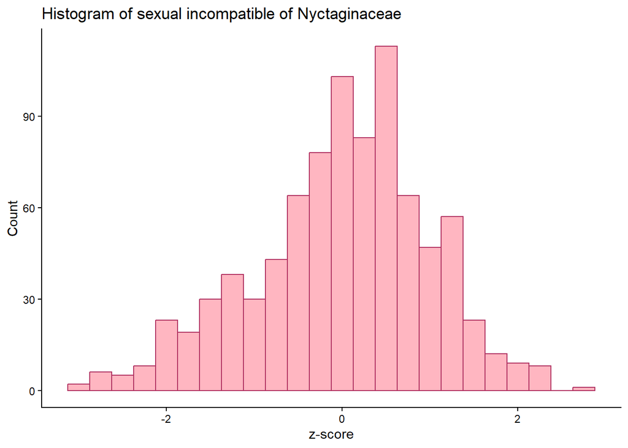

```r
# SI z-scores and plot a histogram of them
SI_data <- floral_data %>% filter(self_inc == "SI")

SI_mean <- mean(SI_data$face_diam_mm, na.rm = TRUE)
SI_sd <- sd(SI_data$face_diam_mm, na.rm = TRUE)
SI_z <- (SI_data$face_diam_mm - SI_mean)/SI_sd

ggplot(data.frame(SI_z), aes(x=SI_z)) + geom_histogram(binwidth = 0.25, fill = "lightpink", colour = "maroon") + labs(title="Histogram of sexual incompatible of Nyctaginaceae", x = "z-score", y = "Count") + theme_classic()
```

```r
# Mean of SC
SC_mean <- floral_data %>% filter(self_inc == "SC") %>% summarise(mean=mean(face_diam_mm, na.rm=TRUE)) %>% pull(mean)
SC_z <- (SC_mean - SI_mean)/SI_sd
print(SC_z)
```

```
## [1] -2.706743
```

```r
# use pnorm()
pnorm(SC_z)
```

```
## [1] 0.003397337
```

**Question 7:** Is this a one-tailed or a two-tailed question, and why? What does the probability say about whether SC flowers are simply small SI flowers?

## 9. Two-sample *t*-test

Test whether SI and SC plants differ in face diameter with a t-test. Report *t*, the degrees of freedom, the p-value and the 95% confidence interval of the difference. Then calculate *t* yourself from the two-sample equation, $t = (\bar x - \bar y) / \sqrt{SE_x^2 + SE_y^2}$, using the standard errors from Section 6, and check that it matches.

```r
# T-test to run...
t_test <- t.test(face_diam_mm ~ self_inc, data=floral_data)

#Test SI and SC
SI_base <- floral_data %>% filter(self_inc == "SI") %>% summarise(n = sum(!is.na(face_diam_mm)), mean = mean(face_diam_mm, na.rm = TRUE), SD = sd(face_diam_mm, na.rm = TRUE))
SC_base <- floral_data %>% filter(self_inc == "SC") %>% summarise(n = sum(!is.na(face_diam_mm)), mean = mean(face_diam_mm, na.rm = TRUE), SD = sd(face_diam_mm, na.rm = TRUE))

# Standard errors
SE_SI <- SI_base$SD / sqrt(SI_base$n)
SE_SC <- SC_base$SD / sqrt(SC_base$n)

# t from sample equation
t_equation <- (SI_base$mean - SC_base$mean) / sqrt(SE_SI^2 + SE_SC^2)

# Comparing!!!
print(t_test)
```

```
##
##  Welch Two Sample t-test
##
## data:  face_diam_mm by self_inc
## t = -43.146, df = 194.45, p-value < 2.2e-16
## alternative hypothesis: true difference in means between group SC and group SI is not equal to 0
## 95 percent confidence interval:
##  -4.793447 -4.374381
## sample estimates:
## mean in group SC mean in group SI
##         5.960045        10.543959
```

```r
print(t_equation)
```

```
## [1] 43.14622
```

**Question 8:** Every statistical test has assumptions. Name two assumptions of the *t*-test and say, in one sentence each, whether you think the *Abronia* data meet them.

**Answer:The t-test assumes that the observations done are independent (the data currently shows a different plant measured in each row). And a second assumption would be that the variable is almost normally distributed within each group (face diameter is a continuous trait in this case and the histogram is bell shaped, hint back to question 2 section 3)**

## 10. Face diameter against tube length

Plot `tube_length_mm` (y) against `face_diam_mm` (x), coloured by `self_inc`, with axis labels with units, a legend title, and a clean theme. Give the figure a caption with the chunk option `fig.cap = "..."`, and hide the code with `echo = FALSE` so that only the figure and its caption appear in the knitted document.

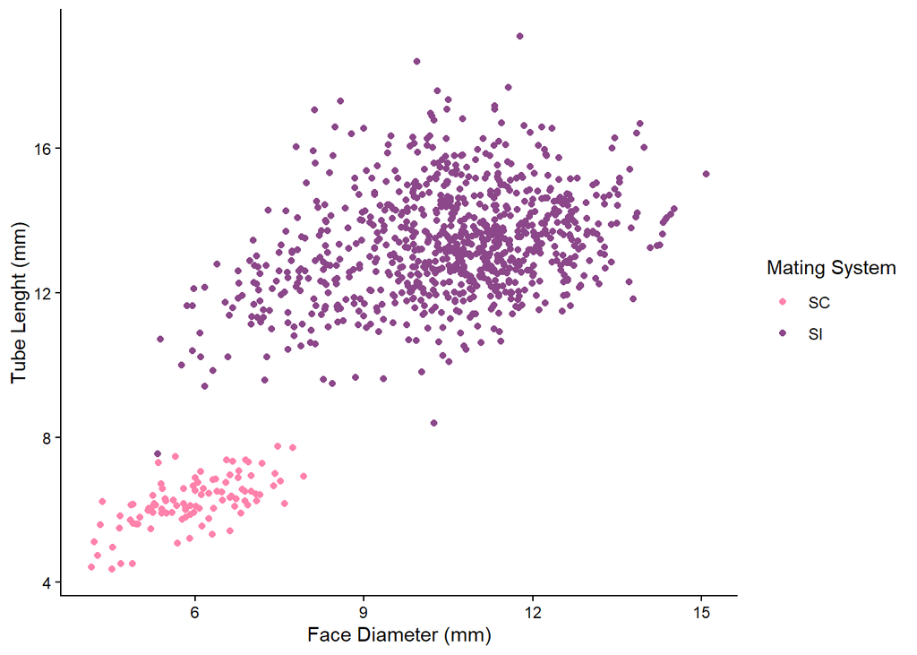

**Question 9:** Using everything above — the site plot in Section 5, the trait means, the *t*-test and this figure — what do the data say about the two hypotheses in the instructions? Answer in a short paragraph.

# DO THIS LAST

When your document is finished, knit it, open the `.html` in a web browser and **print it to PDF** (*File → Print → Save as PDF*; name it `Group_#_CC4.pdf`). Then copy and paste this into the R Console to stop positpal and create your coding log. **Do not include it as a code chunk.**

```
positpal::stop_capture()
positpal::export_capture()
```

`export_capture()` prints the name and location of the `my-capture-YYYYMMDD-HHMMSS.zip` it creates beside this file. **Each group member** uploads their own `.zip` to the **“CC4 — Coding Log (individual)”** dropbox on OnQ; the group’s `.Rmd` and the **`.pdf`** (not the `.html` — OnQ shows uploaded HTML as source code, not as a page) go to your section’s **TUT02-CC4** or **TUT03-CC4** folder. Submissions without the log are incomplete. If `export_capture()` fails, zip the `.capture` folder yourself and upload that instead.